# Cardiovascular Risk Calculator

2016-06-19

## Motivation

- Cardiovascular disease remains the single largest killer in the developed world
- Tools to compute the risk of cardiovascular events help:
  - Physicians risk stratify and manage patients.
  - Educate patients about their risk and what they can do about it.
- A web based calculator of such risk is a most useful tool.
  - This is calculator prototyped using shiny is my project.

## Source

- The equation for the calculator is described in the [2013 Guideline on the Assesment of Cardiovascular Risk](http://bit.ly/1Os6cgR) by the American College of Cardiology and the American Heart Association.
- The guidelines also provide extensive details on its justification and how to apply the tool.
- It meets the needs of working healthcare professionals and patients who wish to understand their risk of cardiovascular disease.

## Example Input and Output

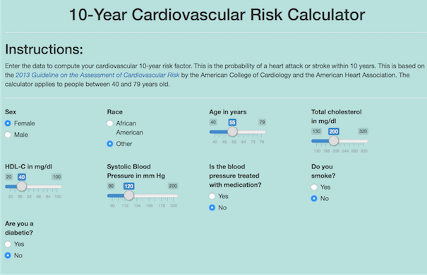

(Input panel to large to embed for interactive slide.)

```
## [1] "10-year cardiovascular risk: 2.4% (embedded R code)"
```

## Shiny Implementation

- Shiny allows for a fast implementation of the calculator using R as an engine.
- The speed allows for creation of multiple prototypes.
- The widgets allow for clean input of the necessary parameters such as age and sex.
  - The user interface follows common browser standards so instructions are nearly unnecessary.
- The shiny app protototype is hosted in [cvCalculator](https://gamercier.shinyapps.io/cvCalculator/)
- An example of the end-product from the AHA/ACC, using javascript, is available at [cvriskcalculator](http://www.cvriskcalculator.com/)

Slidy source hosted in [github cvCalculator_slides](https://github.com/gamercier/cvCalculator_slides/tree/gh-pages)

Shiny app source hosted in [github cvCalculator](https://github.com/gamercier/cvCalculator)